# Problem Sheet 2

Emiko Bell

13/10/2020

# 1. Getting data into R

```r
thedataset <- read.table(here("data/TheDataSet.csv"), sep = " ", header = TRUE)
head(thedataset,n = 5L) %>%
  knitr::kable(digits = 2)
```

| text | is_lure | key | yes_key | rt | group | code | old | correct | success |
| --- | --- | --- | --- | --- | --- | --- | --- | --- | --- |
| b’fish’ | neutral | a | l | 3.83 | 0 | cl98xe | FALSE | FALSE | TRUE |
| b’winter’ | correct | l | l | 1.26 | 0 | cl98xe | TRUE | TRUE | TRUE |
| b’chilly’ | correct | l | l | 0.73 | 0 | cl98xe | TRUE | TRUE | TRUE |
| b’sock’ | neutral | a | l | 0.95 | 0 | cl98xe | FALSE | FALSE | TRUE |
| b’calm’ | neutral | a | l | 1.18 | 0 | cl98xe | FALSE | FALSE | TRUE |

# 2. Exploring data

**2.1.** To get a sense of your data, use the functions summary, str, table. What types are the variables? Guess what the IVs and DVs are?

```r
summary(thedataset)
```

```
##      text             is_lure              key              yes_key
##  Length:1554        Length:1554        Length:1554        Length:1554
##  Class :character   Class :character   Class :character   Class :character
##  Mode  :character   Mode  :character   Mode  :character   Mode  :character
##
##
##
##        rt             group            code              old
##  Min.   :0.1664   Min.   :0.0000   Length:1554        Mode :logical
##  1st Qu.:0.8018   1st Qu.:0.0000   Class :character   FALSE:927
##  Median :1.0043   Median :1.0000   Mode  :character   TRUE :627
##  Mean   :1.2509   Mean   :0.5476
##  3rd Qu.:1.3511   3rd Qu.:1.0000
##  Max.   :8.0371   Max.   :1.0000
##   correct         success
##  Mode :logical   Mode :logical
##  FALSE:942       FALSE:347
##  TRUE :612       TRUE :1207
##
##
##
```

```r
str(thedataset)
```

```
## 'data.frame':    1554 obs. of  10 variables:
##  $ text   : chr  "b'fish'" "b'winter'" "b'chilly'" "b'sock'" ...
##  $ is_lure: chr  "neutral" "correct" "correct" "neutral" ...
##  $ key    : chr  "a" "l" "l" "a" ...
##  $ yes_key: chr  "l" "l" "l" "l" ...
##  $ rt     : num  3.832 1.263 0.73 0.952 1.185 ...
##  $ group  : int  0 0 0 0 0 0 0 0 0 0 ...
##  $ code   : chr  "cl98xe" "cl98xe" "cl98xe" "cl98xe" ...
##  $ old    : logi  FALSE TRUE TRUE FALSE FALSE FALSE ...
##  $ correct: logi  FALSE TRUE TRUE FALSE FALSE TRUE ...
##  $ success: logi  TRUE TRUE TRUE TRUE TRUE FALSE ...
```

```r
table(thedataset$text, thedataset$is_lure)
```

```
##
##                                  correct critical future critical past neutral
##   b'accountant'                        0               0            42       0
##   b'aunt'                              0               0             0      42
##   b'bank'                             42               0             0       0
##   b'bike'                             42               0             0       0
##   b'calm'                              0               0             0      42
##   b'chilly'                           42               0             0       0
##   b'coal'                              0               0             0      42
##   b'construction draftsman'            0               0            42       0
##   b'craftsman'                         0               0            42       0
##   b'data analyst'                      0               0             0      18
##   b'door'                              0               0             0      42
##   b'fish'                              0               0             0      42
##   b'kiwi'                             42               0             0       0
##   b'legs'                             42               0             0       0
##   b'machine learning specialist'       0              42             0       0
##   b'mailman'                           0               0            42       0
##   b'management consultant'             0              42             0       0
##   b'muscle'                            0               0             0      42
##   b'piano'                            42               0             0       0
##   b'plane'                             0               0             0      42
##   b'radio'                            42               0             0       0
##   b'ripe'                             42               0             0       0
##   b'risk manager'                      0              42             0       0
##   b'royal'                             0               0             0      42
##   b'scaffolding worker'               24               0             0       0
##   b'scientist'                         0              42             0       0
##   b'secrtetary'                        0               0            42       0
##   b'smith'                            24               0             0       0
##   b'snooze'                           42               0             0       0
##   b'social media manager'             18               0             0       0
##   b'sock'                              0               0             0      42
##   b'syringe'                           0               0             0      42
##   b'tired'                            42               0             0       0
##   b'ugly'                              0               0             0      42
##   b'user experience designer'          0              42             0       0
##   b'valley'                           42               0             0       0
##   b'wine'                              0               0             0      42
##   b'winter'                           42               0             0       0
##   b'wood'                             42               0             0       0
```

IVs are most likely the text, key, group, old. DVs are most likely rt, correct, and success.

**2.2.** Pretty great that you now have a better understanding of this data set, but in this session we will largely ignore most of it and just focus on the dependent variable rt.

**2.2.1.** Make a new data frame in which you only keep success trials and call it AccData, for “accurate data”.

```r
success <- thedataset["success"]
accdata <- subset(thedataset, success > 0)
#Remember, this is how you took out a category of a variable while leaving the other variables as-is
```

**2.2.2** What is the difference between skew & kurtosis? What is the skew and the kurtosis of the reaction times? Report all major central tendency measures and the dispersion/range of the reaction time distribution. You can answer all of this in 2 lines of code, using 2 functions.

Skew is either positive or negative (tails going to left or right), and the kurtosis is how “sharp” the peak of the distribution is.

```r
describe(accdata) %>%
  knitr::kable(digits = 2)
```

|  | vars | n | mean | sd | median | trimmed | mad | min | max | range | skew | kurtosis | se |
| --- | --- | --- | --- | --- | --- | --- | --- | --- | --- | --- | --- | --- | --- |
| text* | 1 | 1207 | 20.64 | 11.34 | 21.00 | 20.79 | 14.83 | 1.00 | 39.00 | 38.00 | -0.07 | -1.18 | 0.33 |
| is_lure* | 2 | 1207 | 2.48 | 1.31 | 2.00 | 2.48 | 1.48 | 1.00 | 4.00 | 3.00 | 0.03 | -1.73 | 0.04 |
| key* | 3 | 1207 | 1.50 | 0.50 | 2.00 | 1.50 | 0.00 | 1.00 | 2.00 | 1.00 | -0.01 | -2.00 | 0.01 |
| yes_key* | 4 | 1207 | 1.45 | 0.50 | 1.00 | 1.44 | 0.00 | 1.00 | 2.00 | 1.00 | 0.20 | -1.96 | 0.01 |
| rt | 5 | 1207 | 1.22 | 0.75 | 0.99 | 1.07 | 0.34 | 0.17 | 8.04 | 7.87 | 3.39 | 17.20 | 0.02 |
| group | 6 | 1207 | 0.57 | 0.49 | 1.00 | 0.59 | 0.00 | 0.00 | 1.00 | 1.00 | -0.30 | -1.91 | 0.01 |
| code* | 7 | 1207 | 21.92 | 12.05 | 22.00 | 21.99 | 14.83 | 1.00 | 42.00 | 41.00 | -0.03 | -1.20 | 0.35 |
| old | 8 | 1207 | NaN | NA | NA | NaN | NA | Inf | -Inf | -Inf | NA | NA | NA |
| correct | 9 | 1207 | NaN | NA | NA | NaN | NA | Inf | -Inf | -Inf | NA | NA | NA |
| success | 10 | 1207 | NaN | NA | NA | NaN | NA | Inf | -Inf | -Inf | NA | NA | NA |

# 3. First plotting attempts

**3.1.** Install and load ggplot2 Done

**3.2.** Plot reaction time

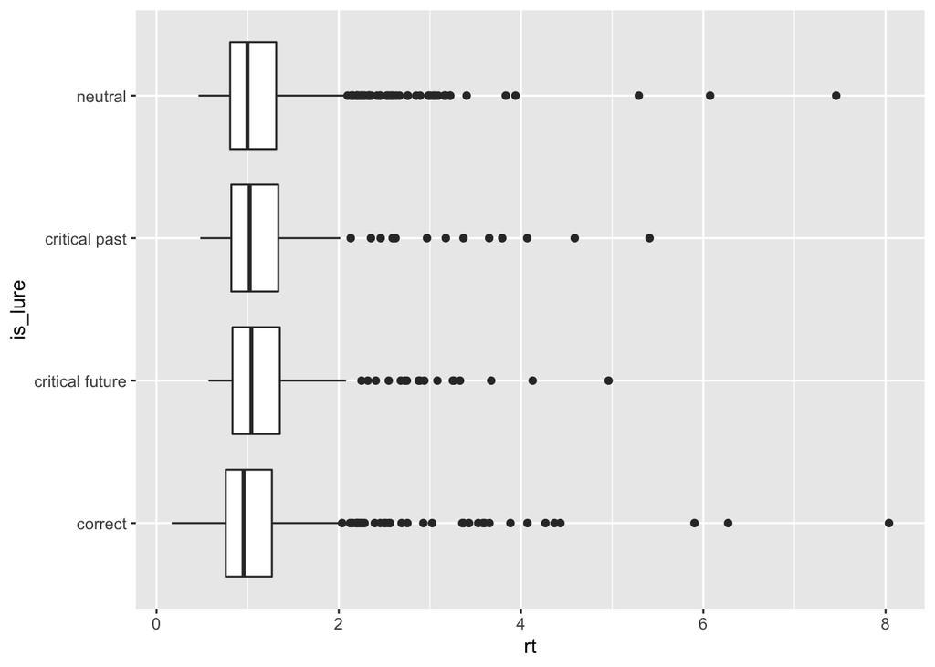

```r
rt <- accdata["rt"]
is_lure <- accdata["is_lure"]
ggplot(data = accdata, aes(x=rt, y= is_lure)) + geom_boxplot()
```

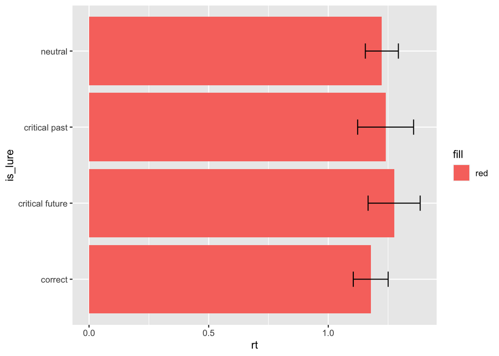

```r
ggplot(data = accdata, aes(x=rt, y=is_lure, fill="red"))+
  stat_summary(fun = "mean", geom = "bar", position="dodge")+
  stat_summary(fun.data = mean_cl_normal, geom="errorbar",
               position = position_dodge(width=0.90), width=0.2)
```

It looks like fun.y no longer works: https://stackoverflow.com/questions/61216963/fun-y-and-stat-summary-stopped-working-in-ggplot

# 4. Assumptions of parametric data

**4.1.** Assumption of normality

**4.1.1.** Plot the distribution

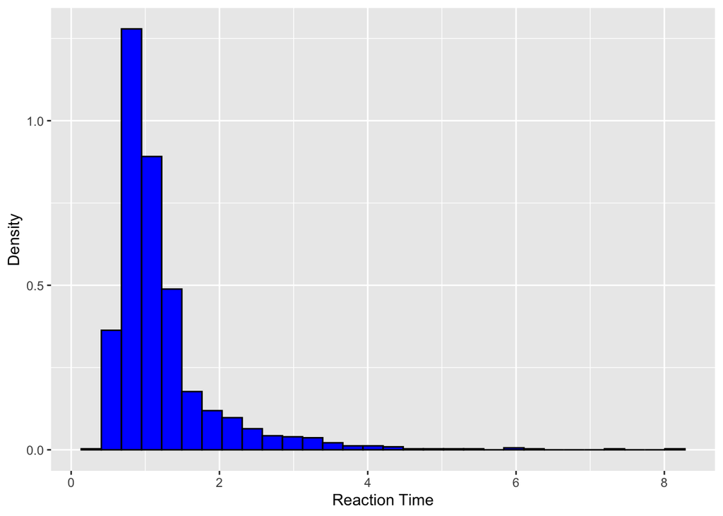

```r
(hits.rt <- ggplot(data = accdata, aes(rt)) + geom_histogram(aes(y=..density..), colour = "black", fill = "blue")) + labs(x = "Reaction Time", y = "Density")
```

**4.1.2.** Add a normally distributed curve as a comparison - pick the mean and SD from the data.

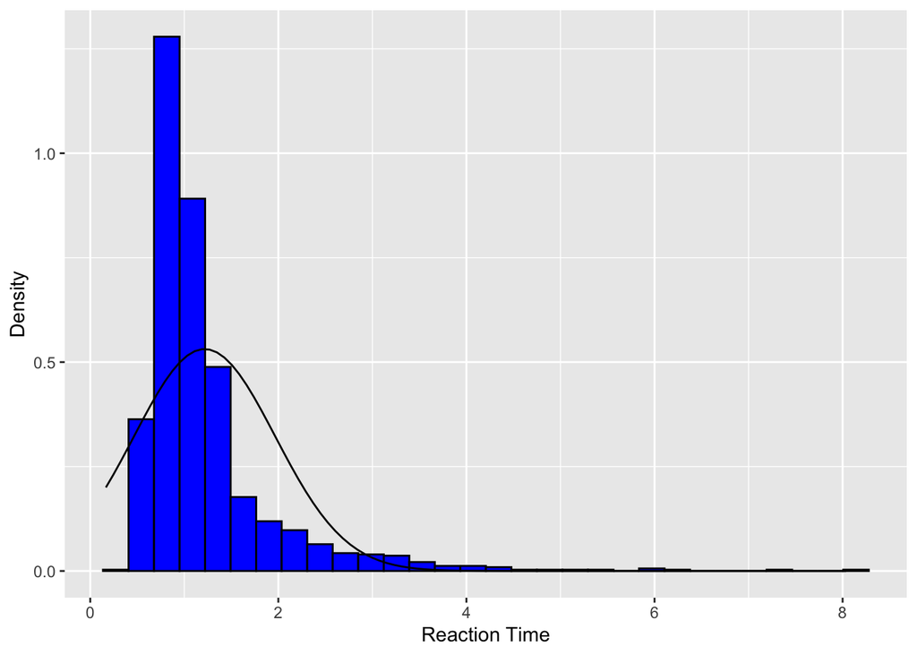

```r
hits.rt + stat_function(fun = dnorm, args = list(mean = mean(accdata$rt, na.rm=T), sd = sd(accdata$rt, na.rm=T))) + labs(x = "Reaction Time", y = "Density")
```

**4.1.3.** Q-Q Plot

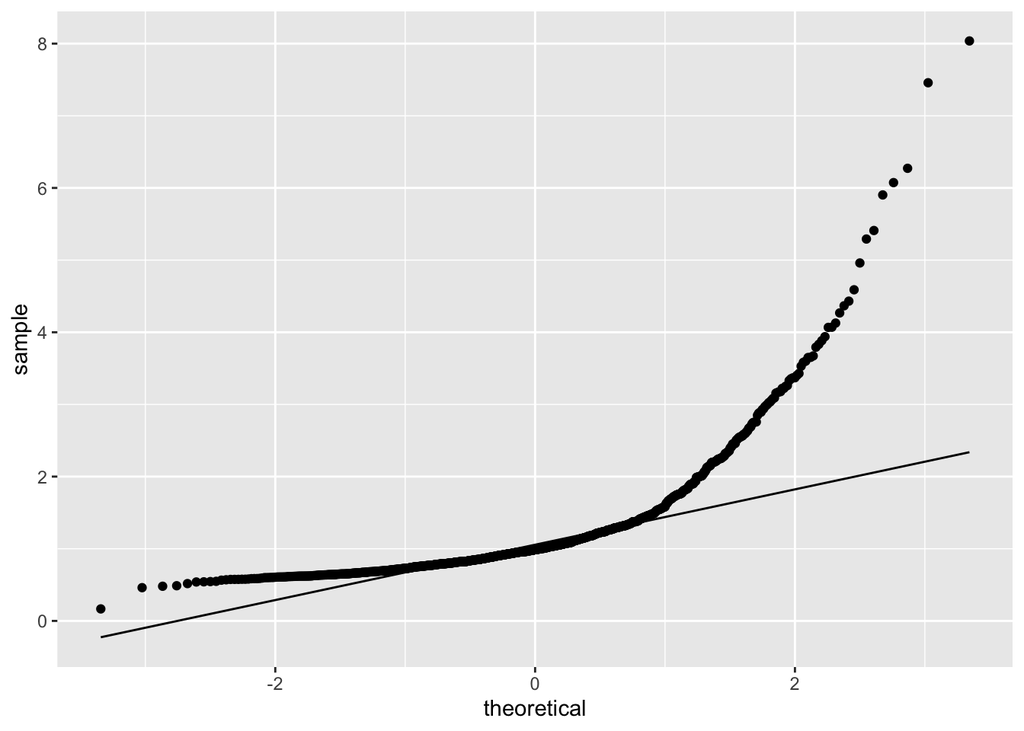

```r
ggplot(accdata, aes(sample = rt)) + stat_qq() + stat_qq_line()
```

The rt data does not necessarily conform to the normal curve – it tapers off after a while.

**4.1.4.**

```r
shapiro.test(accdata$rt)
```

```
##
##  Shapiro-Wilk normality test
##
## data:  accdata$rt
## W = 0.67445, p-value < 2.2e-16
```

The rt data is not normally distributed.

**4.2. Homogeneity of Variance**

```r
leveneTest(accdata$rt, accdata$group)
```

```
## Levene's Test for Homogeneity of Variance (center = median)
##         Df F value Pr(>F)
## group    1   2.247 0.1341
##       1205
```

The groups are homogeneous in variance.

**4.3. Violated Assumptions**

**4.3.1.** **4.3.1.1.-3.**

```r
accdata$logrt <- log(accdata$rt)
accdata$sqrtrt <- sqrt(accdata$rt)
accdata$speed <- 1/rt
describe(accdata$speed)
```

```
##    vars    n mean   sd median trimmed  mad  min  max range skew kurtosis   se
## X1    1 1207    1 0.39   1.01    1.01 0.37 0.12 6.01  5.89 1.72    22.26 0.01
```

The kurtosis is wild…is this considered normal? I think it’s way above the bounds of “normality.” Not sure why this is called speed, other than the data is plotted from the mean of 1 and would show a greater or slower speed.

**4.3.2**

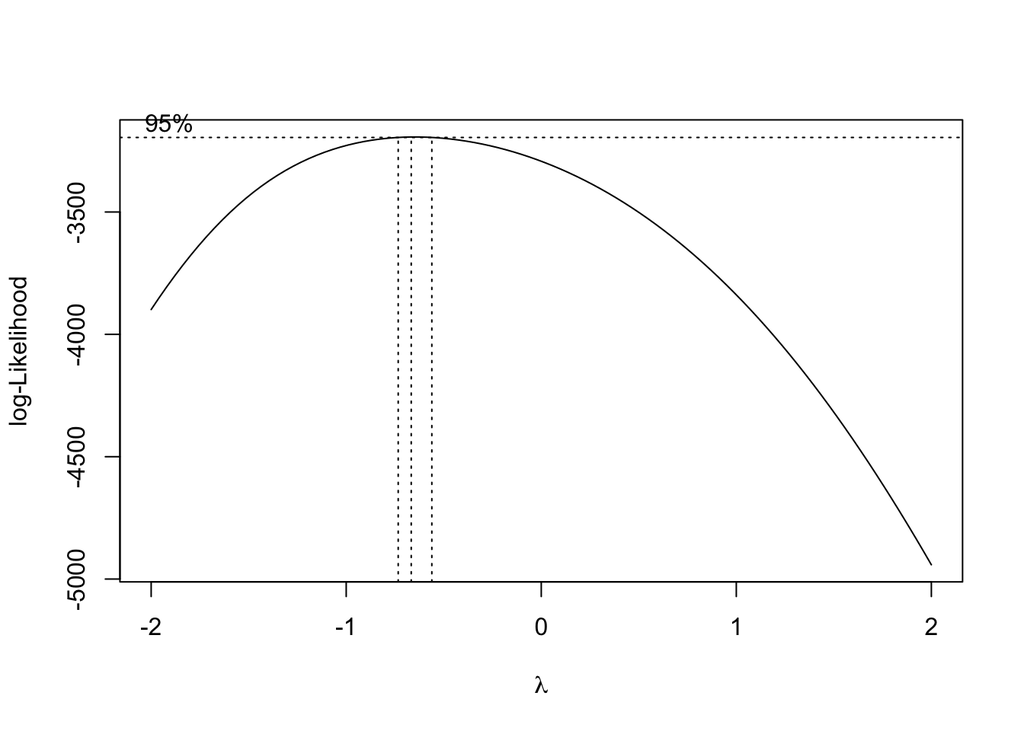

```r
lambdalist <- boxcox(rt~group, data = accdata)
```

```r
lambda <- lambdalist$x[which.max(lambdalist$y)]
```